# Rapport du projet GLM - Assurance non-vie

Analyse des données de catastrophes naturelles en Australie

Yousra Cherkaoui Tangi - Lou Peltier

03 avril, 2020

# 1 Présentation des données et de la problématique

Notre jeu de données est extrait de la librairie *CASdatasets* de R. Il s’agit de *auscathist* qui recense les catastrophes naturelles en Australie à partir de 1967 selon le type de la catastrophe (tempête, incendie, tremblement de terre…), le trimestre ainsi que la localisation géographique. Il y recense le coût original de chaque catastrophe naturelle, ainsi que les coûts normalisés c’est-à-dire les coûts qui prennent en compte l’inflation ainsi que le salaire moyen minimum. Notre jeu de données est constiué de 206 lignes (les années où des catastrophes naturelles ont eu lieu ) surlesquels on mesure 10 variables. Le tableau 1.1 résume les caractéristiques initiales de notre jeu de données :

Table 1.1: Résumé du jeu de données initial auscathist

|  | Year | Quarter | FirstDay | LastDay | Event | Type | Location | OriginalCost | NormCost2011 | NormCost2014 |
| --- | --- | --- | --- | --- | --- | --- | --- | --- | --- | --- |
|  | Min. :1967 | Min. :1.000 | Min. :1967-02-08 | Min. :2007-06-10 | Storm :40 | Length:206 | Sydney : 25 | Min. : 1.3 | Min. : 2.00 | Min. : 2.144 |
|  | 1st Qu.:1987 | 1st Qu.:1.000 | 1st Qu.:1987-03-17 | 1st Qu.:2011-02-07 | Hail :29 | Class :character | Melbourne: 11 | 1st Qu.: 9.0 | 1st Qu.: 28.25 | 1st Qu.: 32.164 |
|  | Median :1998 | Median :2.000 | Median :1998-01-07 | Median :2012-02-15 | Flood, Storm:24 | Mode :character | Brisbane : 10 | Median : 15.0 | Median : 66.00 | Median : 77.195 |
|  | Mean :1995 | Mean :2.243 | Mean :1995-04-11 | Mean :2012-01-31 | Bushfire :19 | NA | : 6 | Mean : 103.6 | Mean : 254.31 | Mean : 287.830 |
|  | 3rd Qu.:2005 | 3rd Qu.:4.000 | 3rd Qu.:2005-02-10 | 3rd Qu.:2013-01-30 | Flood :18 | NA | Perth : 6 | 3rd Qu.: 40.0 | 3rd Qu.: 200.00 | 3rd Qu.: 216.305 |
|  | Max. :2014 | Max. :4.000 | Max. :2014-04-11 | Max. :2014-04-16 | Flooding : 5 | NA | QLD : 4 | Max. :2387.6 | Max. :4296.00 | Max. :4605.932 |
|  | NA | NA | NA | NA’s :189 | (Other) :71 | NA | (Other) :144 | NA | NA’s :16 | NA |

Le tableau 1.2 représente un extrait de notre jeu de données :

Table 1.2: Un extrait de auscathist

| Year | Quarter | FirstDay | LastDay | Event | Type | Location | OriginalCost | NormCost2011 | NormCost2014 |
| --- | --- | --- | --- | --- | --- | --- | --- | --- | --- |
| 2014 | 2 | 2014-04-11 | 2014-04-16 | Cyclone | Cyclone | QLD | 8.4 | NA | 8.487 |
| 2014 | 1 | 2014-01-11 | 2014-01-14 | Bushfires | Bushfire | Perth | 15.0 | NA | 15.228 |
| 2013 | 4 | 2013-10-17 | 2013-10-27 | Bushfires | Bushfire | NSW (various locations) | 183.4 | NA | 187.250 |
| 2013 | 1 | 2013-01-27 | 2013-01-30 | Inundation , Storms | Storm | Northern NSW | 121.3 | NA | 126.749 |
| 2013 | 1 | 2013-01-21 | 2013-01-30 | Inundation , Storms | Storm | QLD | 977.0 | NA | 1020.889 |
| 2013 | 1 | 2013-01-13 | 2013-01-19 | Bushfire | Bushfire | Coonabarabran | 35.0 | NA | 36.572 |

La problématique de ce projet est donc : Comment modéliser la sévérité et la fréquence des sinistres dus aux catastrophes naturelles en Australie ?

Dans un premier temps, nous nous intéressons à la variable OriginalCost que nous cherchons à expliquer en fonction de la localisation géographique, le trimestre ainsi que le type de catastrophe naturelle à travers deux modèles GLMs(Gamma et gaussien). Dans un second temps, nous essayerons d’expliquer la variable fréquence des catastrophes naturelles que nous rajouterons en fonction des mêmes variables explicatives(localisation, trimestre et type) à travers un modèle GLM Poisson.

# 2 Exploration et nettoyage des données :

Bien qu’étant extrait d’une librairie R , notre jeu de données était loin d’être directement exploitable. D’une part, nous avions des données manquantes et des données qui n’étaient pas sous le bon format.

Le tableau 2.1 recense les données manquantes par classes :

Table 2.1: Données manquantes

|  | x |
| --- | --- |
| Year | 0 |
| Quarter | 0 |
| FirstDay | 0 |
| LastDay | 189 |
| Event | 0 |
| Type | 0 |
| Location | 0 |
| OriginalCost | 0 |
| NormCost2011 | 16 |
| NormCost2014 | 0 |

Ce qui peut être résumé par ce graphique :

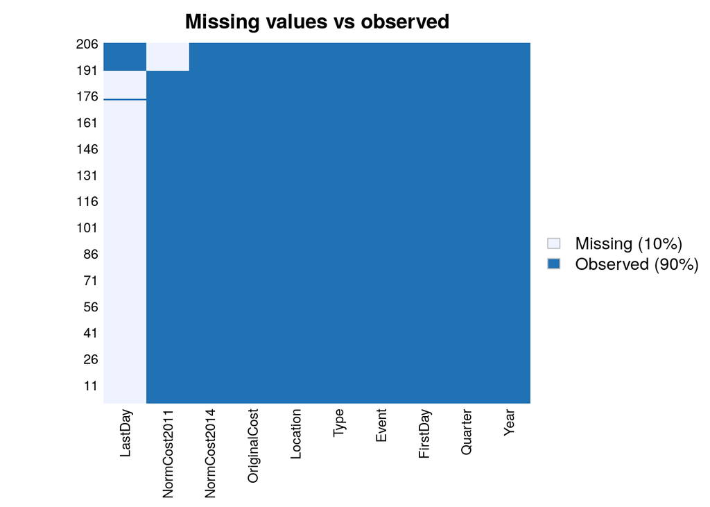

Nous supprimons donc la variable LastDay car elle contient un grand nombre de données manquantes, nous supprimons également toutes les lignes qui contiennent des valeurs manquantes.

Nous nous retrouvons donc avec un jeu de données de 190 lignes et 9 colonnes.

D’autre part et comme le montre cette carte réalisée sous le logiciel Tableau, notre variable Location n’est pas directement exploitable car elle contient 190 classes ce qui représente un grand nombre de classes pour notre GLM.

[figure not shown]

Par conséquent, nous avons rajouté à la main une variable State qui correspond à l’état où la catastrophe naturelle a été observée. Nous nous retrouvons donc avec 12 classes au lieu de 190.

Au final, nous nous retrouvons avec ce jeu de données que nous pouvons directement exploiter cette fois.

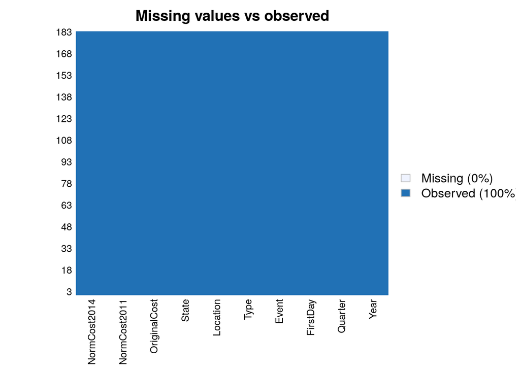

Nos variables explicatives Quarter, State et Type contiennent chacune les classes suivantes :

**Quarter:**

```
## [1] "1" "2" "3" "4"
```

**State :**

```
##  [1] "New South Wales"    "North, West ,VIC"   "Northern Territory"
##  [4] "Queensland"         "SA, TAS, VIC"       "South Australia"
##  [7] "South East Asia"    "Tasmania"           "VIC, QSL, NSW"
## [10] "Victoria"           "Western Australia"  "Widespread"
```

**Type:**

```
## [1] "Bushfire"     "Cyclone"      "Earthquake"   "Flood"        "Flood, Storm"
## [6] "Hailstorm"    "Other"        "Storm"        "Tornado"
```

# 3 GLMs Gamma et Gaussien

## 3.1 Répartition du coût des sinistres en fonction des variables explicatives

Nous souhaitons tout d’abord modéliser la sévérité des sinistres dus aux catastrophes naturelles en Autralie. Pour cela nous voulons expliquer la variable OriginalCost à l’aide de variables explicatives. Afin d’observer le comportement des variables, traçons le coût du sinistre en fonction du trimestre 3.1, du type de catastrophe 3.2 et de la localisation géographique 3.3.

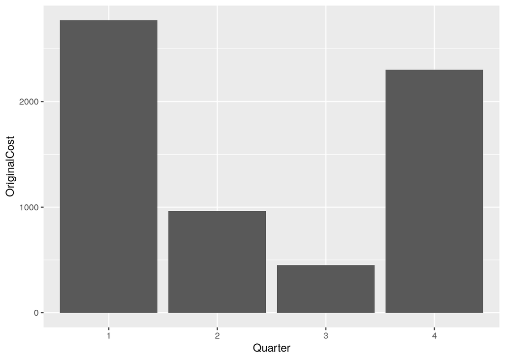

Figure 3.1: Le coût des sinistres par trimestre

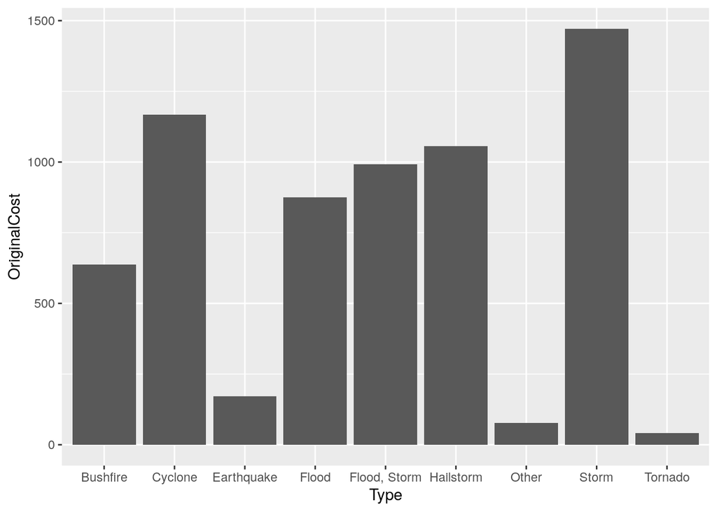

Figure 3.2: Le coût des sinistres par type

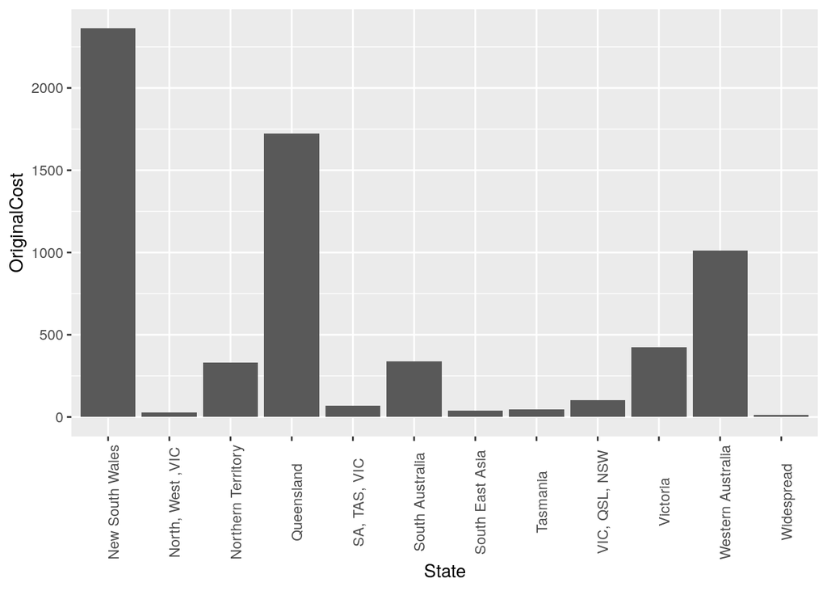

Figure 3.3: Le coût des sinistres par état

Nous pouvons observer que les trimestres 1 et 4 ont une sévérité de sinistres élevée tandis que le troisième trimestre possède un coût relativement faible. Les tremblements de terre et les tornades se distinguent par un faible coût de sinistre et les états New South Wales et Queensland ont un coût bien plus élévé que les autres états.

## 3.2 Modélisation du coût des sinistres par un GLM Gamma

On souhaite effectuer un GLM Gamma sur nos données pour étudier la variable OriginalCost en fonction des variables explicatives. Nous supposons ainsi :
$$Y_i | X_i \sim \ \Gamma \ et \ g(E(Y_i|X_i))=\frac{1}{E(Y_i | X_i)} = X_i^{'}\beta$$
où :

-$Y_i$ correspond au coût du sinistre de la catastrophe i, avec $i =1, …, 183$

-$(X_{i,j})$ représentent les classes des variables explicatives explicitées plus tôt

Table 3.1: Sortie anova Gamma

|  | Df | Deviance | Resid. Df | Resid. Dev | Pr(>Chi) |
| --- | --- | --- | --- | --- | --- |
| NULL | NA | NA | 182 | 128.5433 | NA |
| Quarter | 3 | 1.278801 | 179 | 127.2645 | 0.4502786 |
| State | 11 | 14.003376 | 168 | 113.2611 | 0.0023321 |
| Type | 8 | 4.530610 | 160 | 108.7305 | 0.3129942 |

Cette table d’analyse de la déviance est utile pour la sélection de modèles. Les p-values du test du rapport de vraisemblance indiquent que le modèle composé des variables Quarter et State est significatif au seuil de 5%. Néanmoins cette table ne permet pas de vérifier la significativité de chaque variable.

## 3.3 Choix des variables

Nous allons ainsi tester la significativité de nos variables choisies afin de savoir si elles expliquent le coût des sinistres à l’aide de la fonction Anova du package car .Le tableau 3.2 présente les résultats du test :

Table 3.2: Sortie Anova Gamma pour la significativité

|  | LR Chisq | Df | Pr(>Chisq) |
| --- | --- | --- | --- |
| Quarter | 6.301585 | 3 | 0.0978247 |
| State | 29.659285 | 11 | 0.0017919 |
| Type | 9.358088 | 8 | 0.3129942 |

Le test indique que seule la variable State est significative au seuil de 5%. La variable Quarter est significative au seuil de 10%. La variable Type n’est quand à elle pas significative indiquant que le type de catastrophe naturelle n’a pas d’influence sur le coût du sinistre. Cela semble paradoxal car en regardant le graphique 3.2 on remarque que les Tremblements de Terre, Tornades et Autres ont un coût de sinistre nettement plus faible que les 6 autres types de catastrophes.

Nous allons donc expliquer le coût des sinistres avec la variable State uniquement.

## 3.4 Résultats du GLM Gamma

Le GLM Gamma donne les résultats suivants :

```
##
## Call:
## glm(formula = OriginalCost ~ State, family = Gamma(), data = aus_data_states)
##
## Deviance Residuals:
##      Min        1Q    Median        3Q       Max
## -2.02741  -0.67523  -0.00993   0.39062   1.83929
##
## Coefficients:
##                           Estimate Std. Error t value Pr(>|t|)
## (Intercept)              0.0292125  0.0024207  12.068  < 2e-16 ***
## StateNorth, West ,VIC    0.0052702  0.0238584   0.221  0.82544
## StateNorthern Territory -0.0049701  0.0063769  -0.779  0.43683
## StateQueensland         -0.0071708  0.0034521  -2.077  0.03928 *
## StateSA, TAS, VIC       -0.0142872  0.0105548  -1.354  0.17764
## StateSouth Australia     0.0032358  0.0071561   0.452  0.65171
## StateSouth East Asia    -0.0028967  0.0182748  -0.159  0.87424
## StateTasmania            0.0133407  0.0208523   0.640  0.52318
## StateVIC, QSL, NSW      -0.0003664  0.0117163  -0.031  0.97509
## StateVictoria            0.0247781  0.0081182   3.052  0.00263 **
## StateWestern Australia  -0.0044601  0.0041798  -1.067  0.28746
## StateWidespread          0.0422160  0.0492254   0.858  0.39231
## ---
## Signif. codes:  0 '***' 0.001 '**' 0.01 '*' 0.05 '.' 0.1 ' ' 1
##
## (Dispersion parameter for Gamma family taken to be 0.4737871)
##
##     Null deviance: 128.54  on 182  degrees of freedom
## Residual deviance: 115.71  on 171  degrees of freedom
## AIC: 1658
##
## Number of Fisher Scoring iterations: 6
```

La déviance du modèle correspond à la différence entre le modèle étudié et le modèle saturé qui correspond à un modèle plus général ayant autant de paramètres que de variables réponses, et qui a la même distribution et la même fonction de lien que le modèle étudié. La déviance nulle correspond quand à elle à un modèle avec un seul paramètre.

Nous remarquons que la Residual deviance est inférieure à la Null deviance, ce qui veut dire que le modèle enrichi de la variable explicative State est meilleur que le modèle ne contenant que la constante.

L’AIC est un critère de sélection de modèle, ici ce critère vaut 1658.

La déviance de notre modèle est inférieure à 202.5125774 qui est le quantile d’une chi-deux à 95% à 171 degrés de liberté. L’ajustement de notre modèle semble donc pertinent.

## 3.5 Modélisation du coût des sinistres par un GLM Gaussien

Les résultats obtenus avec le GLM Gamma n’étant pas complètement satisfaisants nous voulons essayer de modéliser le coût des sinistres avec un GLM Gaussien pour comparer les résultats obtenus par les deux modèles et ainsi selectionner le plus pertinent. On suppose alors cette fois :
$$Y_i|X_i \sim \mathcal{N}ormale
\ et \
g(E(Y_i|X_i))=E(Y_i|X_i)=X_i'\beta$$
La fonction de lien choisie est l’identité.

Table 3.3: Sortie anova Gaussian

|  | Df | Deviance | Resid. Df | Resid. Dev | Pr(>Chi) |
| --- | --- | --- | --- | --- | --- |
| NULL | NA | NA | 182 | 99137.52 | NA |
| Quarter | 3 | 1649.678 | 179 | 97487.84 | 0.3286568 |
| State | 11 | 14940.756 | 168 | 82547.09 | 0.0010414 |
| Type | 8 | 5812.976 | 160 | 76734.11 | 0.1458964 |

Le test du rapport de vraisemblance indique que le modèle composé des variables Quarter et State est significatif au seuil de 5%.

## 3.6 Choix des variables

Nous allons ainsi tester la significativité de nos variables choisies afin de savoir si elles expliquent le coût des sinistres à l’aide de la fonction Anova du package car .Le tableau 3.4 présente les résultats du test :

Table 3.4: Sortie Anova Gaussien pour la significativité

|  | LR Chisq | Df | Pr(>Chisq) |
| --- | --- | --- | --- |
| Quarter | 8.326348 | 3 | 0.0397273 |
| State | 32.413547 | 11 | 0.0006545 |
| Type | 12.120766 | 8 | 0.1458964 |

Le test indique que les variables Quarter et State sont significatives au seuil de 5%. On constate que pour ce modèle également la variable Type n’a pas d’influence sur le coût du sinistre engendré par la catastrophe naturelle, ce qui semble paradoxal.

Nous allons ainsi expliquer le coût des sinistres par un GLM Gaussian ayant les variables Quarter et State comme variables explicatives.

## 3.7 Résultats du GLM Gaussien

La modélisation donne le résultat suivant :

```
##
## Call:
## glm(formula = OriginalCost ~ Quarter + State, family = gaussian(),
##     data = aus_data_states)
##
## Deviance Residuals:
##    Min      1Q  Median      3Q     Max
## -46.68  -17.43    0.00   15.71   52.50
##
## Coefficients:
##                         Estimate Std. Error t value Pr(>|t|)
## (Intercept)               31.785      3.449   9.217  < 2e-16 ***
## Quarter2                  -3.810      4.916  -0.775  0.43940
## Quarter3                   1.509      6.562   0.230  0.81845
## Quarter4                   8.161      3.961   2.061  0.04089 *
## StateNorth, West ,VIC     -2.785     22.433  -0.124  0.90136
## StateNorthern Territory    8.733      8.340   1.047  0.29657
## StateQueensland           11.293      4.543   2.486  0.01390 *
## StateSA, TAS, VIC         39.026     22.650   1.723  0.08674 .
## StateSouth Australia      -4.208      7.253  -0.580  0.56256
## StateSouth East Asia      -1.946     22.449  -0.087  0.93104
## StateTasmania            -12.365     15.938  -0.776  0.43893
## StateVIC, QSL, NSW         2.882     13.254   0.217  0.82812
## StateVictoria            -16.445      5.346  -3.076  0.00245 **
## StateWestern Australia     8.735      5.273   1.656  0.09952 .
## StateWidespread          -17.785     22.433  -0.793  0.42902
## ---
## Signif. codes:  0 '***' 0.001 '**' 0.01 '*' 0.05 '.' 0.1 ' ' 1
##
## (Dispersion parameter for gaussian family taken to be 491.3517)
##
##     Null deviance: 99138  on 182  degrees of freedom
## Residual deviance: 82547  on 168  degrees of freedom
## AIC: 1669.8
##
## Number of Fisher Scoring iterations: 2
```

La Residual deviance est inférieure à la Null deviance, ce qui veut dire que le modèle enrichi des variables explicatives Quarter et State est meilleur que le modèle ne contenant que la constante, le modèle expliqué a donc un pouvoir explicatif.

L’AIC est un critère de sélection de modèle, ici ce critère vaut 1669.8.

La déviance résiduelle de notre modèle est largement supérieur à 199.2441769 qui est le quantile d’une chi-deux à 95% à 168 degrés de liberté. Cela signifie que l’ajustement de notre modèle n’est pas pertinent.

La majorité des p-values sont supérieures à 0.05, seulement 4 classes ont une p-values inférieure au seuil de 5%. Cela veut dire que nos variables ne sont pas significatives par rapport aux classes de références choisies.

Ces différentes observations nous indiquent que la modélisation du GLM Gaussien de fonction de lien identité pour expliquer le coût des sinistres en fonction du trimestre et de l’Etat n’est pas pertinente et que nous devons rejeter ce modèle. De plus, l’AIC du GLM Gaussian est supérieur à l’AIC du GLM Gamma (1669.8>1658), indiquant que le modèle Gamma est plus pertinant que le modèle Gaussien.

# 4 GLM Poisson

Nous supposons dans cette partie que

$$Y_i | X_i \sim \ \mathcal{P} \ et \ g(E(Y_i|X_i))=\log({E(Y_i | X_i))} = X_i^{'}\beta$$
où :

-$Y_i$ correspond à la fréquence du sinistre de la catastrophe i, avec $i =1, …, 183$

-$(X_{i,j})$ représentent les classes des variables explicatives explicitées plus tôt

## 4.1 Répartition de la fréquence en fonction des variables explicatives

Notre jeu de données ne contient pas de variable *fréquence des catastrophes naturelles*. Par conséquent, nous la fabriquons nous-mêmes en comptant le nombre de sinistres par année.

Les graphiques 4.1 , 4.2 ainsi que 4.3 nous montrent comment se répartit la fréquence des sinistres en fonction des variables explicatives que nous avons choisies.

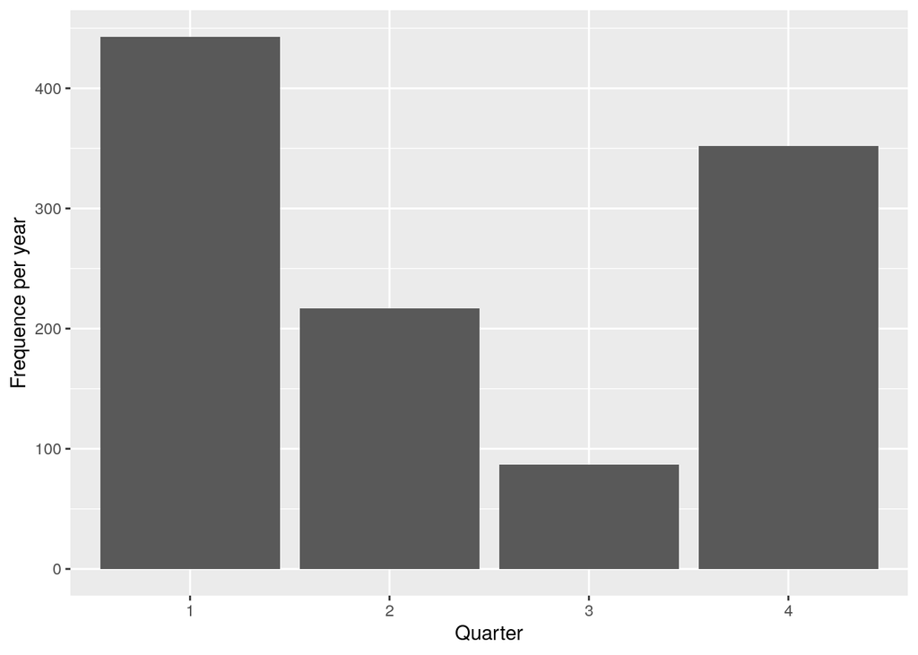

Figure 4.1: La fréquence des sinistres par trimestre

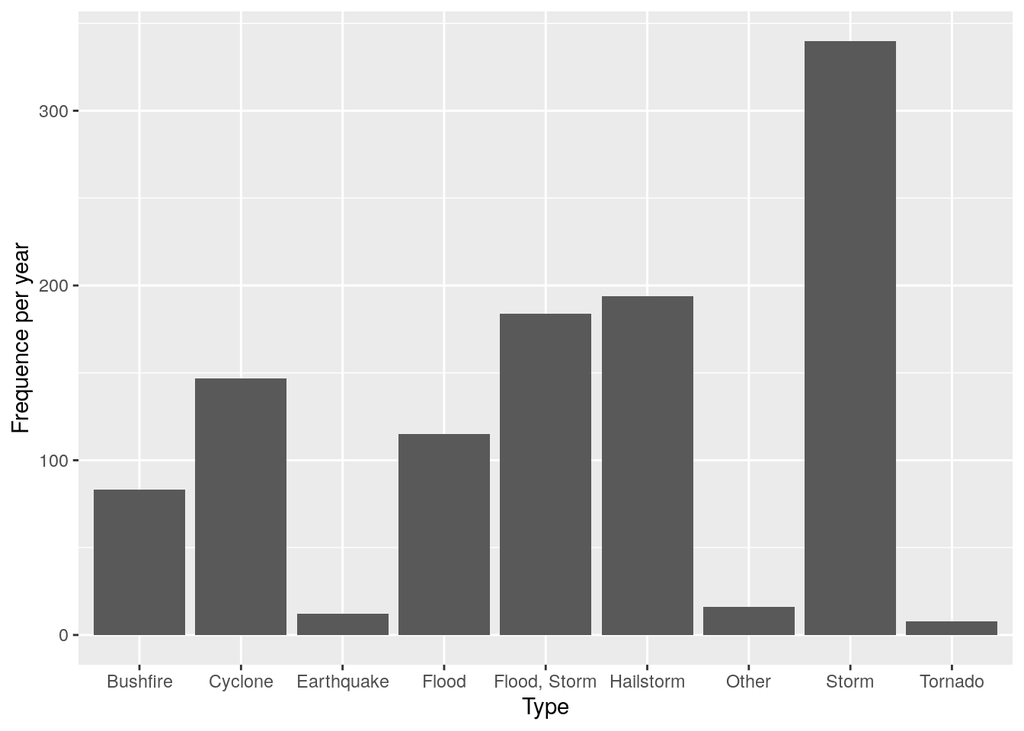

Figure 4.2: La fréquence des sinistres par type

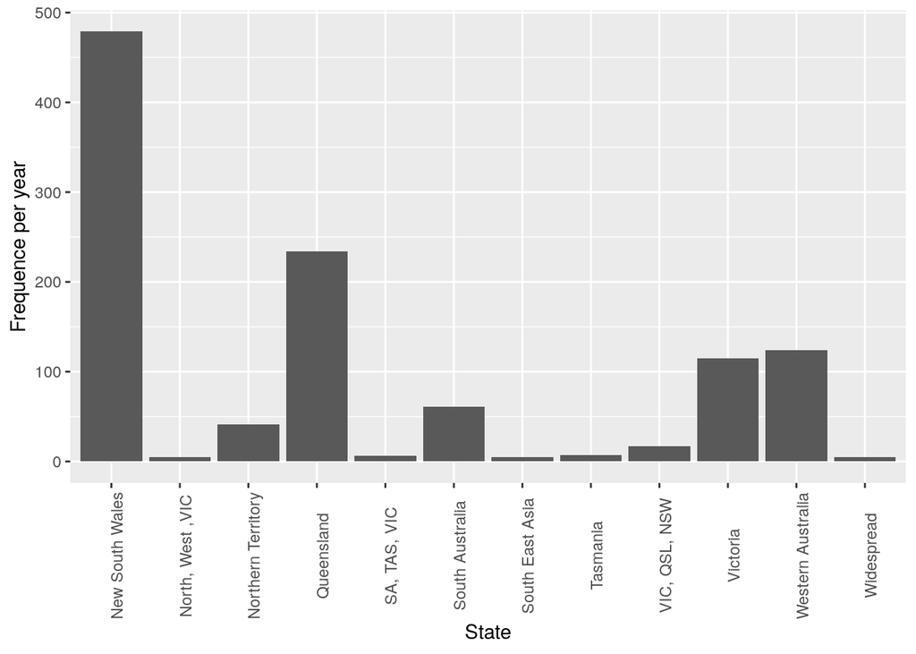

Figure 4.3: La fréquence des sinistres par état

## 4.2 Choix des variables

Nous désirons d’abord tester la significativité de nos variables choisies afin de savoir si elles expliquent la fréquence des sinistres. Le tableau 4.1 présente les résultats du test d’analyse de variance (Anova du package car) :

Table 4.1: Sortie Anova poisson

|  | LR Chisq | Df | Pr(>Chisq) |
| --- | --- | --- | --- |
| Quarter | 12.41885 | 3 | 0.0060778 |
| State | 13.55888 | 11 | 0.2583702 |
| Type | 24.86926 | 8 | 0.0016359 |

Ce test nous montre que la variable State n’est pas significative car sa p-value est supérieure à 5%. Cela veut dire que la localisation géographique des catastrophes naturelles présentes dans notre jeu de données n’influe pas sur leur fréquence. Ce résultat est surprenant car le graphique 4.3 montre que l’état de New South Wales concentre une grande partie des catastrophes naturelles, nous pourrions donc penser qu’il y a plus de chances qu’une catastrophe naturelle ait lieu à New South Wales qu’autre part en Australie mais visiblement ce n’est pas le cas pour ce modèle GLM Poisson à trois variables.

Nous allons donc garder les variables explicatives Quarter et Type et essayer d’expliquer la fréquence des sinistres à partir d’un GLM Poisson.

Les tracés 4.1 , 4.2 montrent qu’on observe le plus grand nombre des sinistres au premier et dernier trimestre de l’année et que les tempêtes sont les catastrophes naturelles les plus fréquentes en Australie.

Du fait que dans la sortie glm de R, les coefficients calculés le sont par rapport à une classe de référence, nous choisissons les classes pour lesquelles on observe les plus petites fréquences afin de repérer facilement les variables significatives dans la sortie R. Nous choisissons donc ces classes de références : le troisième trimestre pour Quarter et Tornado pour Type.

## 4.3 Résultats du GLM Poisson

Notre GLM Poisson nous donne les résultats suivants :

```
##
## Call:
## glm(formula = aus_data$`Frequence per year` ~ Quarter + Type,
##     family = poisson, data = aus_data)
##
## Deviance Residuals:
##     Min       1Q   Median       3Q      Max
## -2.8138  -0.8717  -0.1248   0.6252   3.1163
##
## Coefficients:
##                  Estimate Std. Error z value Pr(>|z|)
## (Intercept)       2.06544    0.37374   5.526 3.27e-08 ***
## Quarter1         -0.06208    0.11985  -0.518   0.6045
## Quarter2          0.23816    0.12995   1.833   0.0669 .
## Quarter4          0.01400    0.12118   0.116   0.9080
## TypeBushfire     -0.44439    0.37352  -1.190   0.2341
## TypeCyclone      -0.49162    0.36794  -1.336   0.1815
## TypeEarthquake   -1.03848    0.45853  -2.265   0.0235 *
## TypeFlood        -0.44729    0.36986  -1.209   0.2265
## TypeFlood, Storm -0.08674    0.36476  -0.238   0.8120
## TypeHailstorm    -0.30344    0.36242  -0.837   0.4024
## TypeOther        -0.46311    0.43584  -1.063   0.2880
## TypeStorm        -0.14957    0.36025  -0.415   0.6780
## ---
## Signif. codes:  0 '***' 0.001 '**' 0.01 '*' 0.05 '.' 0.1 ' ' 1
##
## (Dispersion parameter for poisson family taken to be 1)
##
##     Null deviance: 267.35  on 182  degrees of freedom
## Residual deviance: 221.88  on 171  degrees of freedom
## AIC: 891.83
##
## Number of Fisher Scoring iterations: 4
```

Nous remarquons que la Residual deviance est inférieure à la Null deviance, ce qui veut dire que le modèle enrichi de nos deux variables explicatives est meilleur que le modèle qui ne contient que la constante.

La déviance de notre modèle est supérieure à 202.5125774 qui est le quantile d’une chi-deux à 95% à 171 degrés de liberté. Notre modèle n’est pas bien ajusté.